# Chapter 3 Data overview

This chapter describes the selected Microflora Danica panel before diversity analyses. All summaries are computed from the committed files loaded in the data preparation chapter.

## 3.1 Panel at a glance

```r
overview_numbers <- data.frame(
  Measure = c("Samples", "Habitat classes", "Representative MAGs / 95% ANI clusters",
              "Phylogenetic tree tips", "Sample dates", "Distinct 10 km grid cells",
              "Detected representatives per sample, median (range)",
              "Zero entries in abundance matrix"),
  Value = c(
    nrow(overview_samples), length(habitat_levels), nrow(genome_metadata),
    ape::Ntip(genome_tree),
    paste(format(range(overview_samples$date), "%Y-%m-%d"), collapse = " to "),
    length(unique(overview_samples$cell.10km)),
    sprintf("%.0f (%d–%d)", median(detected_per_sample),
            min(detected_per_sample), max(detected_per_sample)),
    sprintf("%.1f%%", 100 * mean(overview_abundance == 0))
  )
)
knitr::kable(overview_numbers)
```

| Measure | Value |
| --- | --- |
| Samples | 360 |
| Habitat classes | 8 |
| Representative MAGs / 95% ANI clusters | 5518 |
| Phylogenetic tree tips | 5518 |
| Sample dates | 2014-10-16 to 2023-01-27 |
| Distinct 10 km grid cells | 251 |
| Detected representatives per sample, median (range) | 114 (4–298) |
| Zero entries in abundance matrix | 97.7% |

The abundance matrix contains **relative abundances within the published MFD MAG profile**, not sequencing counts or the fraction of all DNA. A detected representative means a strictly positive value in that profile. This threshold includes very small reported values, so detected richness should be interpreted with that sensitivity in mind.

## 3.2 Geographic coverage

The selection contains 45 samples per habitat class. The table shows the observed coordinate span and the number of occupied 10 km grid cells within each class; grid-cell counts need not sum to the panel total because classes can share cells.

```r
habitat_rows <- lapply(habitat_levels, function(h) {
  d <- overview_samples[overview_samples$habitat_label == h, ]
  data.frame(
    Habitat = h,
    Samples = nrow(d),
    `10 km cells` = length(unique(d$cell.10km)),
    `Latitude °N` = sprintf("%.2f–%.2f", min(d$latitude), max(d$latitude)),
    `Longitude °E` = sprintf("%.2f–%.2f", min(d$longitude), max(d$longitude)),
    check.names = FALSE
  )
})
knitr::kable(do.call(rbind, habitat_rows))
```

| Habitat | Samples | 10 km cells | Latitude °N | Longitude °E |
| --- | --- | --- | --- | --- |
| Agricultural field soil | 45 | 45 | 54.75–57.58 | 8.20–12.53 |
| Natural grassland soil | 45 | 45 | 54.64–57.63 | 8.14–15.09 |
| Natural forest soil | 45 | 45 | 54.72–57.66 | 8.16–15.02 |
| Urban greenspace soil | 45 | 45 | 54.75–57.73 | 8.21–14.92 |
| Natural bog/fen soil | 45 | 45 | 54.76–57.64 | 8.24–15.02 |
| Natural freshwater sediment | 45 | 45 | 54.60–57.58 | 8.13–14.95 |
| Natural saltwater sediment | 45 | 45 | 54.85–57.75 | 8.12–14.91 |
| Urban wastewater water | 45 | 45 | 54.65–57.74 | 8.24–12.31 |

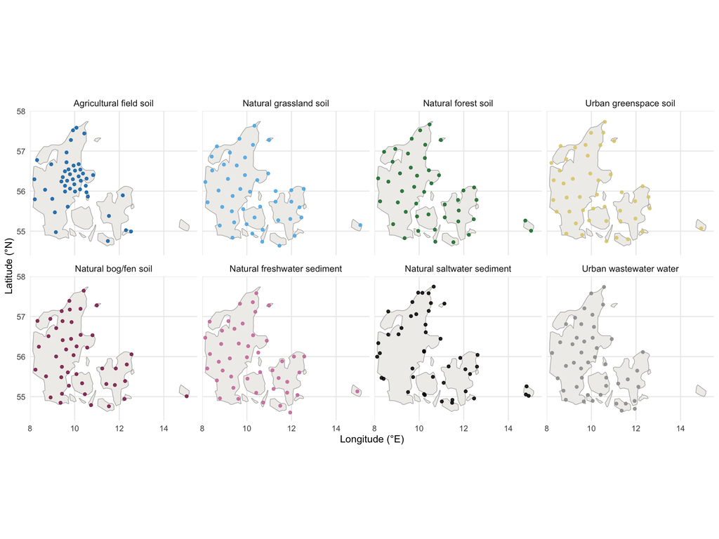

```r
denmark <- ggplot2::map_data("world", region = "Denmark")
ggplot2::ggplot() +
  ggplot2::geom_polygon(
    data = denmark,
    ggplot2::aes(x = long, y = lat, group = group),
    fill = "#f0eeeb", colour = "#a9aaa8", linewidth = 0.25
  ) +
  ggplot2::geom_point(
    data = overview_samples,
    ggplot2::aes(x = longitude, y = latitude, colour = habitat_label),
    alpha = 0.85, size = 1.2
  ) +
  ggplot2::scale_colour_manual(values = habitat_colours, guide = "none") +
  ggplot2::facet_wrap(~ habitat_label, ncol = 4) +
  ggplot2::coord_quickmap(xlim = c(8, 15.5), ylim = c(54.4, 58.0), expand = FALSE) +
  ggplot2::labs(x = "Longitude (°E)", y = "Latitude (°N)") +
  ggplot2::theme_minimal(base_size = 10) +
  ggplot2::theme(panel.grid.minor = ggplot2::element_blank(),
                 strip.text = ggplot2::element_text(size = 9))
```

*Sample locations by habitat class. The Denmark outline includes Bornholm.*

The map shows sample coordinates, including freshwater, saltwater, and wastewater sites. It does not encode sampling effort in the source atlas; the 45-per-class selection was deliberately balanced and geographically dispersed.

## 3.3 Sampling time

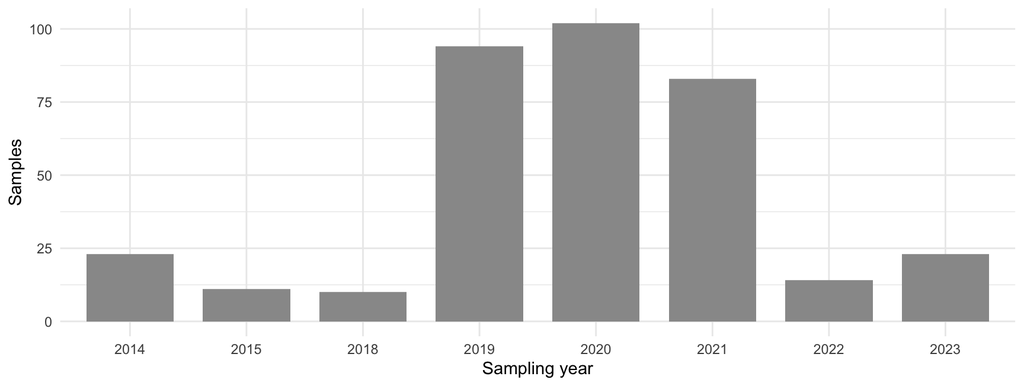

```r
overview_samples$year <- format(overview_samples$date, "%Y")
ggplot2::ggplot(overview_samples, ggplot2::aes(x = year)) +
  ggplot2::geom_bar(fill = "#999999", width = 0.75) +
  ggplot2::labs(x = "Sampling year", y = "Samples") +
  ggplot2::theme_minimal(base_size = 11)
```

*Sampling years of the selected panel.*

## 3.4 Representative genomes

```r
domain_counts <- as.data.frame(table(sub("^d__", "", genome_metadata$domain)))
names(domain_counts) <- c("Domain", "Representatives")
knitr::kable(domain_counts)
```

| Domain | Representatives |
| --- | --- |
| Archaea | 223 |
| Bacteria | 5295 |

```r
phylum <- sub("^p__", "", genome_metadata$phylum)
phylum[is.na(phylum) | phylum == ""] <- "Unclassified"
phylum_counts <- sort(table(phylum), decreasing = TRUE)
top_phyla <- data.frame(
  Phylum = names(head(phylum_counts, 10)),
  Representatives = as.integer(head(phylum_counts, 10))
)
knitr::kable(top_phyla)
```

| Phylum | Representatives |
| --- | --- |
| Pseudomonadota | 1563 |
| Actinomycetota | 1083 |
| Acidobacteriota | 736 |
| Bacteroidota | 376 |
| Chloroflexota | 232 |
| Patescibacteria | 193 |
| Desulfobacterota | 132 |
| Verrucomicrobiota | 121 |
| Bacillota | 87 |
| Cyanobacteriota | 84 |

There are 422 high-quality and 5096 medium-quality representatives under the source metadata’s classifications. Each representative stands for a 95% ANI cluster in the abundance table; the table above counts representatives, not all MAGs assigned to those clusters.